# Beta diversity of microbes during inulin treatment

Roger Calvas

2025-05-02

# Goals

1. Load in phyloseq data with rooted tree & colors and functions.
2. Evaluate sequencing depth and remove samples, if needed.
3. Normalize the read counts between samples.
4. Calculate community **dis**similarities. Numbers between 0 and 1. If 0, completely similar versus if they are 1, then they’re completely dissimilar.
   1. **Sorensen**: Shared Species as a binary value: Abundance-unweighted
   2. **Bray-Curtis**: Shared Abundant species: Abundance-weighted
   3. **(Abundance-)Weighted UNIFRAC**: Consider Abundant Species and where they fall on the tree
5. Run statistics with functions from the vegan R package:
   1. PERMANOVA with `adonis2()`.
   2. betadispR with `betadisper()` and `permutest()`.
6. Visualize the community data with two unconstrained Ordinations:
   1. **PCoA**: Linear Method. Eigenvalue = how much variation is explained by each axis. Choose to view axis 1, 2, 3, etc. and plot them together.
   2. **NMDS**: Non-linear. Smush multiple Dimensions into 2 or 3 axes. Need to report Stress value (ideally <0.15).
1. We will need the `phytree_preprocessed_physeq.RData`

## Outputs

*This is an exciting analysis!!! We get to answer another one of our scientific questions!*

1. Calculated beta-diversity dissimilarity measures (*e.g.* Sorensen, Bray-Curtis, abundance-unweighted and -weighted UniFrac) across every sample.
2. Ordination figures (*i.e.,* PCoA/NMDS) to include in the scientific paper that visualize the data as it relates to the scientific question.
3. Statistical tests (*i.e.,* PERMANOVA & betadisper) conveying the measured and quantified changes and patterns in biodiversity.

# Scientific Question

Does inulin treatment increase SCFA production (i.e., acetate, butyrate, propionate), and is this associated with a shift in fiber-fermenting bacteria?

- *Null Hypothesis:* Microbial diversity and scfa production does not vary during inulin treatment.
- *Alternative Hypothesis:* An inulin treatment will stimulate scfa production and shift microbial composition.

INTERPRETATION #1: What is your scientific question and hypotheses? Do they relate to abundance? Presence/absence? Phylogeny?

Does inulin treatment increase SCFA production (i.e., acetate, butyrate, propionate), and is this associated with a shift in fiber-fermenting bacteria?

- *Null Hypothesis:* Microbial diversity and scfa production does not vary during inulin treatment.
- *Alternative Hypothesis:* An inulin treatment will stimulate scfa production and shift microbial composition.

## Timing of this script

```r
# What time did we start running this script?
start_time <- Sys.time()
```

## Set the seed

```r
set.seed(39809473)
```

## Load Packages, colors & functions

```r
pacman::p_load(tidyverse, devtools, phyloseq, patchwork, vegan,
               install = FALSE)

# Load Colors
source("code/colors.R")

# Load functions
source("code/functions.R")
```

# 1. Load in the data

```r
# load phyloseq object
load("data/04_Phylogenetic_Tree/archaeal_rooted_physeq.RData")
archaeal_rooted_physeq
```

```
## phyloseq-class experiment-level object
## otu_table()   OTU Table:         [ 1980 taxa and 161 samples ]
## sample_data() Sample Data:       [ 161 samples by 54 sample variables ]
## tax_table()   Taxonomy Table:    [ 1980 taxa by 9 taxonomic ranks ]
## phy_tree()    Phylogenetic Tree: [ 1980 tips and 1979 internal nodes ]
```

```r
# Intuition check on seq depth
min(sample_sums(archaeal_rooted_physeq))
```

```
## [1] 7215
```

# Normalizing the Read Depth

## 2. Explore the Raw Read Counts

```r
# calculate read counts per sample
raw_TotalSeqs_df <-
  archaeal_rooted_physeq %>%
  # Calculate the total number of sequences/reads
  sample_sums() %>%
  data.frame()

# Take a look
head(raw_TotalSeqs_df)
```

```
##                .
## SRR6443836 19399
## SRR6443839 27322
## SRR6443844  9565
## SRR6443871 28582
## SRR6443905 15277
## SRR6443910 16349
```

```r
# Rename the column
colnames(raw_TotalSeqs_df)[1] <- "TotalSeqs"

# add a new column of num_ASVs (RAW, non-noramlized # ASVs)
raw_TotalSeqsASVs_df <-
  raw_TotalSeqs_df %>%
  mutate(num_ASVs = colSums(otu_table(archaeal_rooted_physeq) > 1))

#View(raw_TotalSeqsASVs_df)

# Plot histogram of seq depth
rawSeq_histogram <-
  raw_TotalSeqsASVs_df %>%
  ggplot(aes(x = TotalSeqs)) +
  geom_histogram(bins = 50) +
  scale_x_continuous(limits = c(0, 35000)) +
  labs(title = "Raw Seq Depth Histogram") +
  theme_bw()

# Plot Seq Depth versus num_ASVs
rawSeq_vs_numASV_plot <-
  raw_TotalSeqsASVs_df %>%
  ggplot(aes(x = num_ASVs, y = TotalSeqs)) +
  geom_point() +
  scale_y_continuous(limits = c(0, 35000)) +
  geom_smooth(method = "lm") +
  labs(title = "Seq Depth vs # ASVs") +
  theme_bw()

# is it significant?
summary(lm(TotalSeqs ~ num_ASVs, data = raw_TotalSeqsASVs_df))
```

```
##
## Call:
## lm(formula = TotalSeqs ~ num_ASVs, data = raw_TotalSeqsASVs_df)
##
## Residuals:
##      Min       1Q   Median       3Q      Max
## -10811.6  -3872.1   -662.2   3586.1  14339.9
##
## Coefficients:
##             Estimate Std. Error t value Pr(>|t|)
## (Intercept)  9676.90    1468.93   6.588 6.21e-10 ***
## num_ASVs       66.27      12.77   5.189 6.37e-07 ***
## ---
## Signif. codes:  0 '***' 0.001 '**' 0.01 '*' 0.05 '.' 0.1 ' ' 1
##
## Residual standard error: 5209 on 159 degrees of freedom
## Multiple R-squared:  0.1448, Adjusted R-squared:  0.1394
## F-statistic: 26.92 on 1 and 159 DF,  p-value: 6.373e-07
```

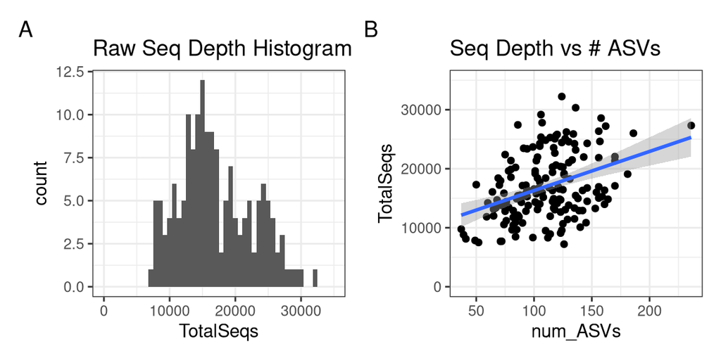

```r
# Put the two plots together.
rawSeq_histogram + rawSeq_vs_numASV_plot +
  plot_annotation(tag_levels = "A")
```

INTERPRETATION #2: Evaluating the above plots, what did you scale the read counts to in your dataset? Why did you choose that number? Do you think it is sufficient to perform a beta-diversity analysis and accurately compare your data to one another?

I chose the minimun sequencing depth in the dataset at 7k~ because even thought plot B shows a positive correlation between sequencing depth and number of ASVs but it is not too steep, also based on the spread of the scatterplot and the fact that the minimum is not an outlier it seems like sufficient lenght. There is an outlier with unusually high count of ASVs so I will keep an eye on it.

# 3. Scale Read Counts

```r
min(sample_sums(archaeal_rooted_physeq))
```

```
## [1] 7215
```

```r
# Scale the reads
scaled_physeq <-
  archaeal_rooted_physeq %>%
  scale_reads(round = "matround")

# Look at it
scaled_physeq
```

```
## phyloseq-class experiment-level object
## otu_table()   OTU Table:         [ 1976 taxa and 161 samples ]
## sample_data() Sample Data:       [ 161 samples by 54 sample variables ]
## tax_table()   Taxonomy Table:    [ 1976 taxa by 9 taxonomic ranks ]
## phy_tree()    Phylogenetic Tree: [ 1976 tips and 1975 internal nodes ]
```

```r
# Save it
save(scaled_physeq, file ="data/06_Ordination/scaled_physeq.RData")

#Prune NA values for beta diversity analysis
scaled_physeq <-
  scaled_physeq %>%
  subset_samples(!is.na(total_scfa))

# Look at it more!
#View(data.frame(otu_table(archaeal_rooted_physeq)))
#View(data.frame(otu_table(scaled_physeq)))

# Confirm seq read depth of scaled_physeq
scaled_TotalSeqs_df <-
  scaled_physeq %>%
  sample_sums() %>%
  data.frame()

colnames(scaled_TotalSeqs_df)[1] <- "TotalSeqs"

# add a new column of num_ASVs (RAW, non-noramlized # ASVs)
scaled_TotalSeqsASVs_df <-
  scaled_TotalSeqs_df %>%
  mutate(num_ASVs = colSums(otu_table(scaled_physeq) > 1))

# Plot it!
scaledSeq_histogram <-
  scaled_TotalSeqs_df %>%
  ggplot(aes(x = TotalSeqs)) +
  geom_histogram(bins = 50) +
  labs(title = "Scaled Seq Depth Histogram") +
  scale_x_continuous(limits = c(0, 10000)) +
  theme_bw()

# Scaling always gives us a range!
# MInimum sequences
min(scaled_TotalSeqs_df$TotalSeqs)
```

```
## [1] 7191
```

```r
# Total Range
range(scaled_TotalSeqs_df)
```

```
## [1] 7191 7225
```

```r
# How many is that range?
range_seqs <- (max(scaled_TotalSeqs_df$TotalSeqs) - min(scaled_TotalSeqs_df$TotalSeqs))
range_seqs
```

```
## [1] 34
```

```r
# And in terms of percent?
range_seqs/max(scaled_TotalSeqs_df$TotalSeqs)
```

```
## [1] 0.004705882
```

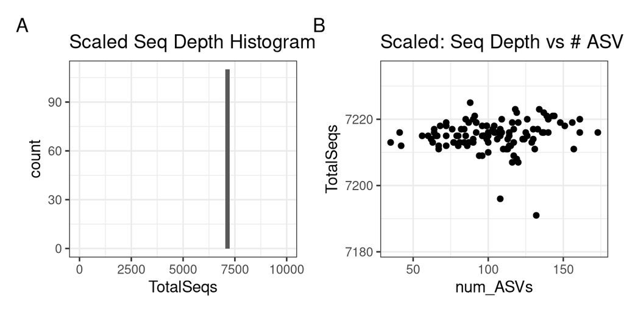

```r
#View(scaled_TotalSeqs_df)

# Set the axis min and max for the next plot
max_y <- max(scaled_TotalSeqs_df$TotalSeqs) + 10
min_y <- min(scaled_TotalSeqs_df$TotalSeqs) - 10

# Now, draw the plot
scaledSeq_vs_numASV_plot <-
  scaled_TotalSeqsASVs_df %>%
  ggplot(aes(x = num_ASVs, y = TotalSeqs)) +
  geom_point() +
  scale_y_continuous(limits = c(min_y, max_y)) +
  #geom_smooth(method = "lm") +
  theme_bw() +
  labs(title = "Scaled: Seq Depth vs # ASVs")

# Put the two plots together.
scaledSeq_histogram + scaledSeq_vs_numASV_plot +
  plot_annotation(tag_levels = "A")
```

## Create metadata after pruning

```r
# Create Metadata_df after the prune
metadata_df <-
  scaled_physeq %>%
  sample_data() %>%
  data.frame()
```

INTERPRETATION #3: Evaluate the scaled read count plots above. Are the total number of sequences across all of your samples in the same general range? What is the minimum and maximum (i.e., the range) of the sequencing depth? How was the relationship with the number of ASVs modified after scaling the read counts?

##Calculate dissimilarity

```r
#Jaccard Dissimilarity
scaled_jaccard_dist <- phyloseq::distance(scaled_physeq, method = "jaccard", binary = TRUE)

# What does it look like?
class(scaled_jaccard_dist)
```

```
## [1] "dist"
```

```r
str(scaled_jaccard_dist)
```

```
##  'dist' num [1:5995] 0.689 0.676 0.707 0.681 0.635 ...
##  - attr(*, "maxdist")= num 1
##  - attr(*, "Size")= int 110
##  - attr(*, "Labels")= chr [1:110] "SRR6443836" "SRR6443844" "SRR6443871" "SRR6443923" ...
##  - attr(*, "Diag")= logi FALSE
##  - attr(*, "Upper")= logi FALSE
##  - attr(*, "method")= chr "binary jaccard"
##  - attr(*, "call")= language vegdist(x = c(0, 0, 0, 0, 0, 0, 0, 0, 0, 0, 0, 0, 0, 0, 0, 0, 0, 0, 0,  0, 0, 0, 0, 0, 0, 0, 0, 0, 0, 0, 0, 0, 0,| __truncated__ ...
```

```r
#head(as.matrix(scaled_jaccard_dist))

scaled_sorensen_dist <- phyloseq::distance(scaled_physeq, method = "bray", binary = TRUE)

# Bray-Curtis Dissimiliarty
scaled_Bray_dist <- phyloseq::distance(scaled_physeq, method = "bray", binary = FALSE)

# Abundance-Unweighted UniFrac
scaled_uUnifrac_dist <- phyloseq::distance(scaled_physeq, method = "unifrac")

# Abundance-Weighted UniFrac
scaled_wUnifrac_dist <- phyloseq::distance(scaled_physeq, method = "wunifrac")
```

INTERPRETATION #4: Which dissimilarity metric is most related to your scientific question? Why or why not?

I think bray curtis would be the most related to my scientific question, since I am looking for shifts in the dinamics of the community I want to look closely into relative abundance changes during the treatment, also find specific taxa that increased in response to inulin and that are related to scfa production from fermentable fiber, unifrac is a close second because I want to see the shifts in the structure of the community.

### Permanova continous variable with total_scfa

```r
# bray
## 1. Run with by = terms for R² values, sensitive to order of variables!
## ALWAYS check and confirm the order of your terms and how they interact with each other.
bray_status_adonis_terms1 <- adonis2(scaled_Bray_dist ~ status + total_scfa, data = metadata_df, by = "terms")
bray_status_adonis_terms1
```

```
## Permutation test for adonis under reduced model
## Terms added sequentially (first to last)
## Permutation: free
## Number of permutations: 999
##
## adonis2(formula = scaled_Bray_dist ~ status + total_scfa, data = metadata_df, by = "terms")
##             Df SumOfSqs      R2      F Pr(>F)
## status       1   0.3533 0.01225 1.3450  0.165
## total_scfa   1   0.3913 0.01356 1.4897  0.097 .
## Residual   107  28.1079 0.97419
## Total      109  28.8525 1.00000
## ---
## Signif. codes:  0 '***' 0.001 '**' 0.01 '*' 0.05 '.' 0.1 ' ' 1
```

```r
# Check the order of the terms
bray_status_adonis_terms2 <- adonis2(scaled_Bray_dist ~ total_scfa + status, data = metadata_df, by = "terms")
bray_status_adonis_terms2
```

```
## Permutation test for adonis under reduced model
## Terms added sequentially (first to last)
## Permutation: free
## Number of permutations: 999
##
## adonis2(formula = scaled_Bray_dist ~ total_scfa + status, data = metadata_df, by = "terms")
##             Df SumOfSqs      R2      F Pr(>F)
## total_scfa   1   0.3891 0.01349 1.4812  0.083 .
## status       1   0.3555 0.01232 1.3535  0.137
## Residual   107  28.1079 0.97419
## Total      109  28.8525 1.00000
## ---
## Signif. codes:  0 '***' 0.001 '**' 0.01 '*' 0.05 '.' 0.1 ' ' 1
```

```r
## 2. Run with by = "margin" for marginal p-values, which we can compare to the residuals from the first one.
bray_status_adonis_margin <- adonis2(scaled_Bray_dist ~ total_scfa * status, data = metadata_df, by = "margin")
bray_status_adonis_margin
```

```
## Permutation test for adonis under reduced model
## Marginal effects of terms
## Permutation: free
## Number of permutations: 999
##
## adonis2(formula = scaled_Bray_dist ~ total_scfa * status, data = metadata_df, by = "margin")
##                    Df SumOfSqs      R2      F Pr(>F)
## total_scfa:status   1   0.2028 0.00703 0.7702  0.703
## Residual          106  27.9051 0.96716
## Total             109  28.8525 1.00000
```

### Permanova continous variable with total_scfa

```r
# sorensen
## 1. Run with by = terms for R² values, sensitive to order of variables!
## ALWAYS check and confirm the order of your terms and how they interact with each other.
sorensen_status_adonis_terms1 <- adonis2(scaled_sorensen_dist ~ status + total_scfa, data = metadata_df, by = "terms")
sorensen_status_adonis_terms1
```

```
## Permutation test for adonis under reduced model
## Terms added sequentially (first to last)
## Permutation: free
## Number of permutations: 999
##
## adonis2(formula = scaled_sorensen_dist ~ status + total_scfa, data = metadata_df, by = "terms")
##             Df SumOfSqs      R2      F Pr(>F)
## status       1   0.2159 0.01020 1.1151  0.302
## total_scfa   1   0.2389 0.01128 1.2337  0.195
## Residual   107  20.7181 0.97852
## Total      109  21.1729 1.00000
```

```r
# Check the order of the terms
sorensen_status_adonis_terms2 <- adonis2(scaled_sorensen_dist ~ total_scfa + status, data = metadata_df, by = "terms")
sorensen_status_adonis_terms2
```

```
## Permutation test for adonis under reduced model
## Terms added sequentially (first to last)
## Permutation: free
## Number of permutations: 999
##
## adonis2(formula = scaled_sorensen_dist ~ total_scfa + status, data = metadata_df, by = "terms")
##             Df SumOfSqs      R2      F Pr(>F)
## total_scfa   1   0.2377 0.01123 1.2276  0.213
## status       1   0.2171 0.01025 1.1212  0.296
## Residual   107  20.7181 0.97852
## Total      109  21.1729 1.00000
```

```r
## 2. Run with by = "margin" for marginal p-values, which we can compare to the residuals from the first one.
sorensen_status_adonis_margin <- adonis2(scaled_sorensen_dist ~ total_scfa * status, data = metadata_df, by = "margin")
sorensen_status_adonis_margin
```

```
## Permutation test for adonis under reduced model
## Marginal effects of terms
## Permutation: free
## Number of permutations: 999
##
## adonis2(formula = scaled_sorensen_dist ~ total_scfa * status, data = metadata_df, by = "margin")
##                    Df SumOfSqs      R2      F Pr(>F)
## total_scfa:status   1   0.1594 0.00753 0.8218   0.68
## Residual          106  20.5587 0.97099
## Total             109  21.1729 1.00000
```

### Permanova continous for each scfa with bray

```r
bray_status_adonis_propionate1 <- adonis2(scaled_Bray_dist ~ status + propionate, data = metadata_df, by = "terms")
bray_status_adonis_propionate1
```

```
## Permutation test for adonis under reduced model
## Terms added sequentially (first to last)
## Permutation: free
## Number of permutations: 999
##
## adonis2(formula = scaled_Bray_dist ~ status + propionate, data = metadata_df, by = "terms")
##             Df SumOfSqs      R2      F Pr(>F)
## status       1   0.3533 0.01225 1.3410  0.153
## propionate   1   0.3092 0.01072 1.1736  0.267
## Residual   107  28.1900 0.97704
## Total      109  28.8525 1.00000
```

```r
# Check the order of the terms
bray_status_adonis_propionate2 <- adonis2(scaled_Bray_dist ~ propionate + status, data = metadata_df, by = "terms")
bray_status_adonis_propionate2
```

```
## Permutation test for adonis under reduced model
## Terms added sequentially (first to last)
## Permutation: free
## Number of permutations: 999
##
## adonis2(formula = scaled_Bray_dist ~ propionate + status, data = metadata_df, by = "terms")
##             Df SumOfSqs      R2      F Pr(>F)
## propionate   1   0.3076 0.01066 1.1675  0.281
## status       1   0.3549 0.01230 1.3471  0.152
## Residual   107  28.1900 0.97704
## Total      109  28.8525 1.00000
```

```r
bray_status_adonis_Butyrate1 <- adonis2(scaled_Bray_dist ~ status + Butyrate, data = metadata_df, by = "terms")
bray_status_adonis_Butyrate1
```

```
## Permutation test for adonis under reduced model
## Terms added sequentially (first to last)
## Permutation: free
## Number of permutations: 999
##
## adonis2(formula = scaled_Bray_dist ~ status + Butyrate, data = metadata_df, by = "terms")
##           Df SumOfSqs      R2      F Pr(>F)
## status     1   0.3533 0.01225 1.3474  0.165
## Butyrate   1   0.4428 0.01535 1.6888  0.048 *
## Residual 107  28.0564 0.97241
## Total    109  28.8525 1.00000
## ---
## Signif. codes:  0 '***' 0.001 '**' 0.01 '*' 0.05 '.' 0.1 ' ' 1
```

```r
# Check the order of the terms
bray_status_adonis_Butyrate2 <- adonis2(scaled_Bray_dist ~ Butyrate + status, data = metadata_df, by = "terms")
bray_status_adonis_Butyrate2
```

```
## Permutation test for adonis under reduced model
## Terms added sequentially (first to last)
## Permutation: free
## Number of permutations: 999
##
## adonis2(formula = scaled_Bray_dist ~ Butyrate + status, data = metadata_df, by = "terms")
##           Df SumOfSqs      R2      F Pr(>F)
## Butyrate   1   0.4406 0.01527 1.6804  0.046 *
## status     1   0.3555 0.01232 1.3558  0.139
## Residual 107  28.0564 0.97241
## Total    109  28.8525 1.00000
## ---
## Signif. codes:  0 '***' 0.001 '**' 0.01 '*' 0.05 '.' 0.1 ' ' 1
```

```r
bray_status_adonis_acetate1 <- adonis2(scaled_Bray_dist ~ status + acetate, data = metadata_df, by = "terms")
bray_status_adonis_acetate1
```

```
## Permutation test for adonis under reduced model
## Terms added sequentially (first to last)
## Permutation: free
## Number of permutations: 999
##
## adonis2(formula = scaled_Bray_dist ~ status + acetate, data = metadata_df, by = "terms")
##           Df SumOfSqs      R2      F Pr(>F)
## status     1   0.3533 0.01225 1.3517  0.140
## acetate    1   0.5320 0.01844 2.0352  0.022 *
## Residual 107  27.9672 0.96932
## Total    109  28.8525 1.00000
## ---
## Signif. codes:  0 '***' 0.001 '**' 0.01 '*' 0.05 '.' 0.1 ' ' 1
```

```r
# Check the order of the terms
bray_status_adonis_acetate2 <- adonis2(scaled_Bray_dist ~ acetate + status, data = metadata_df, by = "terms")
bray_status_adonis_acetate2
```

```
## Permutation test for adonis under reduced model
## Terms added sequentially (first to last)
## Permutation: free
## Number of permutations: 999
##
## adonis2(formula = scaled_Bray_dist ~ acetate + status, data = metadata_df, by = "terms")
##           Df SumOfSqs      R2      F Pr(>F)
## acetate    1   0.5313 0.01841 2.0325  0.015 *
## status     1   0.3540 0.01227 1.3544  0.157
## Residual 107  27.9672 0.96932
## Total    109  28.8525 1.00000
## ---
## Signif. codes:  0 '***' 0.001 '**' 0.01 '*' 0.05 '.' 0.1 ' ' 1
```

INTERPRETATION #5: Using the above example to guide you, run the appropriate PERMANOVA for your scientific question and interpret the results. What biological conclusion can you draw from your PERMANOVA results?

# 5b. Betadisper: Testing Variances/Dispersions

## Sorensen

```r
# Homogeneity of Disperson test with beta dispr
# Sorensen Betadisper - status
dispr_sorensen_status <- betadisper(scaled_sorensen_dist, metadata_df$status)
# permutest() performs a non-parametric permutation test, which is robust and valid for the kind of data used in beta diversity analysis (e.g., dissimilarity matrices).
permutest(dispr_sorensen_status)
```

```
##
## Permutation test for homogeneity of multivariate dispersions
## Permutation: free
## Number of permutations: 999
##
## Response: Distances
##            Df  Sum Sq   Mean Sq     F N.Perm Pr(>F)
## Groups      1 0.00000 0.0000012 2e-04    999  0.991
## Residuals 108 0.54345 0.0050320
```

```r
# Sorensen Betadisper - propionate
dispr_sorensen_propionate<- betadisper(scaled_sorensen_dist, metadata_df$propionate)
permutest(dispr_sorensen_propionate)
```

```
##
## Permutation test for homogeneity of multivariate dispersions
## Permutation: free
## Number of permutations: 999
##
## Response: Distances
##            Df Sum Sq Mean Sq   F N.Perm Pr(>F)
## Groups    109      0       0 NaN    999
## Residuals   0      0     NaN
```

```r
# Sorensen Betadisper - Butyrate
dispr_sorensen_Butyrate<- betadisper(scaled_sorensen_dist, metadata_df$Butyrate)
permutest(dispr_sorensen_Butyrate)
```

```
##
## Permutation test for homogeneity of multivariate dispersions
## Permutation: free
## Number of permutations: 999
##
## Response: Distances
##            Df Sum Sq Mean Sq   F N.Perm Pr(>F)
## Groups    109      0       0 NaN    999
## Residuals   0      0     NaN
```

### Now lets test with bray curtis

```r
# Bray-Curtis Betadisper - Status
dispr_bray_status<- betadisper(scaled_Bray_dist, metadata_df$status)
permutest(dispr_bray_status)
```

```
##
## Permutation test for homogeneity of multivariate dispersions
## Permutation: free
## Number of permutations: 999
##
## Response: Distances
##            Df  Sum Sq  Mean Sq      F N.Perm Pr(>F)
## Groups      1 0.00035 0.000351 0.0385    999  0.854
## Residuals 108 0.98464 0.009117
```

```r
# Bray-Curtis Betadisper - propionate
dispr_bray_propionate <- betadisper(scaled_Bray_dist, metadata_df$propionate)
permutest(dispr_bray_propionate)
```

```
##
## Permutation test for homogeneity of multivariate dispersions
## Permutation: free
## Number of permutations: 999
##
## Response: Distances
##            Df Sum Sq Mean Sq   F N.Perm Pr(>F)
## Groups    109      0       0 NaN    999
## Residuals   0      0     NaN
```

```r
# Bray-Curtis Betadisper - Butyrate
dispr_bray_Butyrate <- betadisper(scaled_Bray_dist, metadata_df$Butyrate)
permutest(dispr_bray_Butyrate)
```

```
##
## Permutation test for homogeneity of multivariate dispersions
## Permutation: free
## Number of permutations: 999
##
## Response: Distances
##            Df Sum Sq Mean Sq   F N.Perm Pr(>F)
## Groups    109      0       0 NaN    999
## Residuals   0      0     NaN
```

INTERPRETATION #6: Using the above example to guide you, run the appropriate betadisper() and permutest() for your scientific question and interpret the results. What biological conclusion can you draw from your dispersion analysis?

INTERPRETATION #7: Taking into account both the betadisper()/permutest() and the PERMANOVA (adonis2()) test that you ran, what biological conclusion can you draw regarding your data?